# Parameterize an Albers Equal Area projection

Michael France Nelson

May 11, 2020

# This page describes how to choose appropriate parameters for an Albers Equal Area conic projection for a region of interest.

# Scenario

- You want to choose an appropriate Albers Equal Area projection for some spatial data.
- You need a practical way to choose parameter values use for the projection, based on the locaiton of your data.

# Summary

Use the following steps to find the four parameters you need to define an acceptable Albers Equal Area projection for your data:

1. Get the lat/long coordinates of the bounding box of your data
2. Calculate:
1. The longitude at the midpoint of the bounding box
2. The latitude at the midpoint of the bounding box
3. The min and max latitudes of the bounding box

The four parameters you need are:

- `lat_1` = min latitude of the bounding box + 1/6 latitude range
- `lat_2` = max latitude of the bounding box - 1/6 latitude range
- `lat_0` = the latitude at the midpoint
- `lon_0` = the longitude at the midpoint

Assemble them into the proj4 string using your parameter values:

“+proj=aea +lat_1=_____ +lat_2=_____ +lat_0=_____ +lon_0=_____”

# Background

## proj4

To see the proj4 string format, here’s an example (the AEA projection used by USGS)

“+proj=aea +lat_1=29.5 +lat_2=45.5 +lat_0=37.5 +lon_0=-96 +x_0=0 +y_0=0 +ellps=GRS80 +datum=NAD83 +units=m +no_defs”

This example has values for all of the parameters, optional and required.

## Required parameters

First standard parallel.

- Format: +lat_1=
- Defaults to 0.0.

Second standard parallel.

- Format: +lat_2=
- Defaults to 0.0.

## Optional parameters

### Longitude of projection center.

- Format: +lon_0=
- Defaults to 0.0.

### Latitude of projection center.

- Format: +lat_0=
- Defaults to 0.0.

### Ellipsoid

- Format: +ellps=
- Defaults to “GRS80”.

### Radius of the sphere

Given in meters.

If used in conjunction with +ellps +R takes precedence.

- Format +R=

### False easting.

- Format: +x_0=
- Defaults to 0.0.

### False northing.

- Format: +y_0=
- Defaults to 0.0.

## Some references

https://proj.org/operations/projections/aea.html https://www.bluemarblegeo.com/knowledgebase/GeoCalcPBW/Content/ClassDef/Projection/Projections/AlbersEqualArea.html http://www.georeference.org/doc/albers_conical_equal_area.htm

# Data Setup

We’ll use polygon data for the state borders of Massachusetts as an example data set.

Package `spData` has an `sf` object containing polygon data for all the US State borders.

```r
require(spData)
```

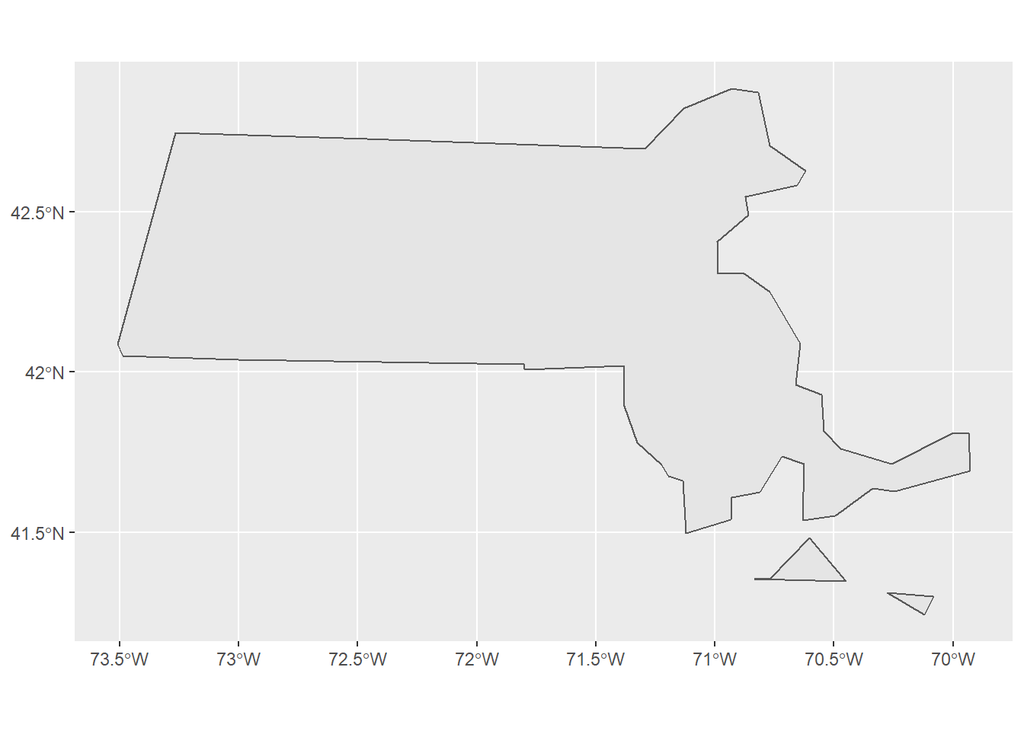

```r
mass_border_sf = subset(us_states, NAME == "Massachusetts")
ggplot(mass_border_sf) + geom_sf()
```

We’ll make a `SpatialPolygonsDataFrame` object to demo the procedure in both the `spatial` and `sf` paradigms

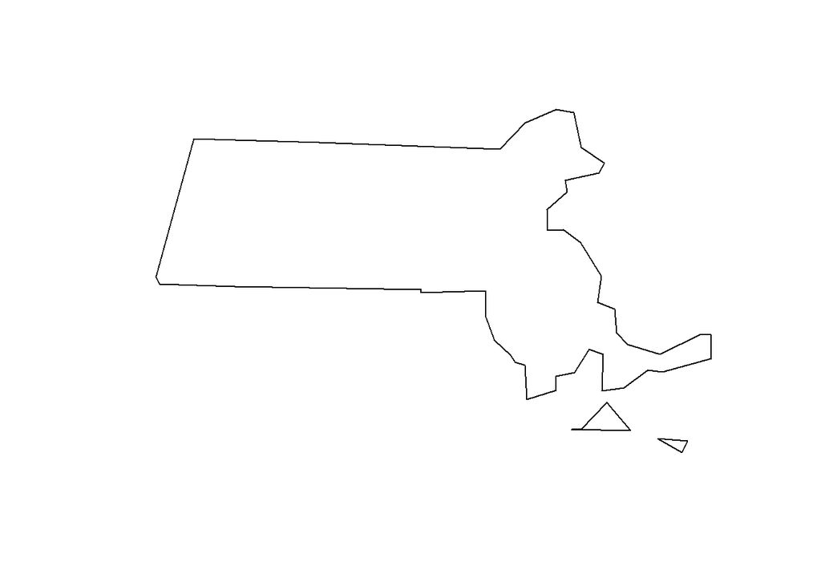

```r
mass_border_sp = as(mass_border_sf, "Spatial")
plot(mass_border_sp)
```

We can check the current projection:

```r
st_crs(mass_border_sf)
```

```
## Coordinate Reference System:
##   EPSG: 4269
##   proj4string: "+proj=longlat +datum=NAD83 +no_defs"
```

```r
proj4string(mass_border_sp)
```

```
## [1] "+proj=longlat +datum=NAD83 +no_defs +ellps=GRS80 +towgs84=0,0,0"
```

# Procedure

## Determine the lon/lat values of the bounding box of your area of interest

```r
bbox(mass_border_sp)
```

```
##         min       max
## x -73.50814 -69.92826
## y  41.24235  42.88459
```

```r
st_bbox(mass_border_sf)
```

```
##      xmin      ymin      xmax      ymax
## -73.50814  41.24235 -69.92826  42.88459
```

## The “one-sixth” rule

A rule of thumb is to choose standard parallels at 1/6 and 5/6 the range of latitudes.

These standard parallels are the required parameters to specify an Albers Equal Area projection:

### In `sp`

`bbox()` returns the bounding box coordinates in a table. We can access the `ymin` and `ymax` slots using array indices:

`extent()` returns an **S4** `Extent` object. We can access the `ymin` and `ymax` slots using the `@` symbol:

```r
bbox(mass_border_sp)[1, ]
```

```
##       min       max
## -73.50814 -69.92826
```

```r
# diff(bbox(mass_border_sp)[2, ])
# yrange_sp = ymax_sp - ymin_sp

bbox_mass_sp = bbox(mass_border_sp)

ymin_sp = bbox_mass_sp[2, 1]
ymax_sp = bbox_mass_sp[2, 2]
yrange_sp = ymax_sp - ymin_sp

# yrange_sp = diff(bbox(mass_border_sp)[2, ])

proj4_aea_sp =
  paste0(
    "+proj=aea",
    " +lat_1=",
    ymin_sp + yrange_sp / 6,
    " +lat_2=",
    ymax_sp - yrange_sp / 6)
```

### In `sf`

The `st` bbox implementation does not return a `S4` object, but we can get the y range using the dollar sign:

```r
ymin_sf = st_bbox(mass_border_sf)$ymin
ymax_sf = st_bbox(mass_border_sf)$ymax

yrange_sf = ymax_sf - ymin_sf

proj4_aea_sf =
  paste0(
    "+proj=aea",
    " +lat_1=",
    ymin_sf + yrange_sf / 6,
    " +lat_2=",
    ymax_sf - yrange_sf / 6)
```

### Plot

Plot to check if it worked:

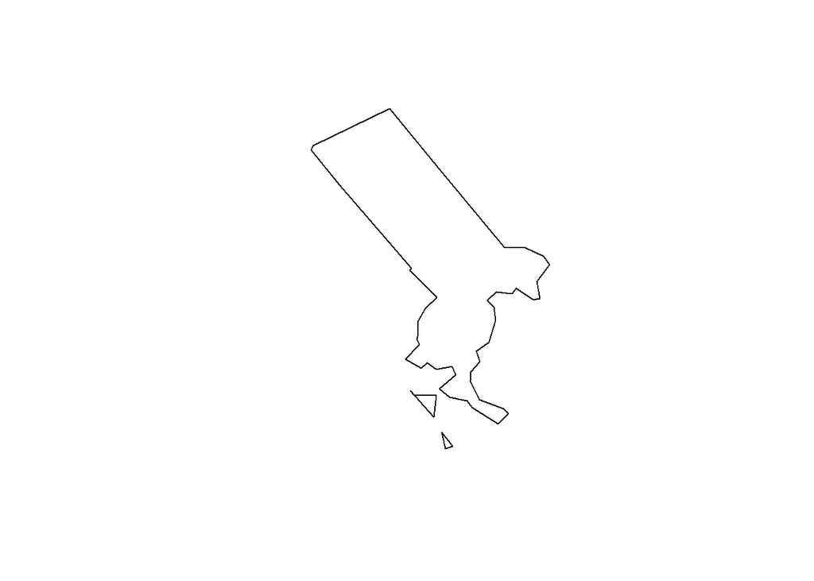

```r
plot(spTransform(mass_border_sp, proj4_aea_sp))
```

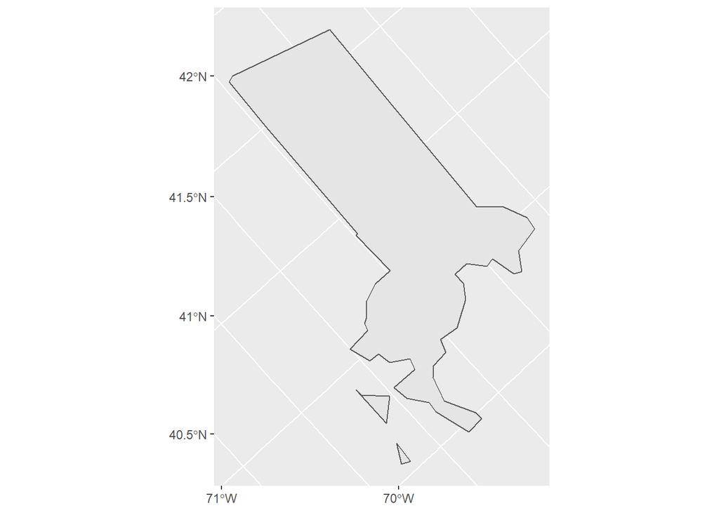

```r
ggplot(st_transform(mass_border_sf, proj4_aea_sp)) + geom_sf()
```

Something’s wrong!

## Specify projection center

We didn’t specify the projection center longitude or latitude. Both default to 0, which is nowhere near Massachusetts!

For simplicity, use the long/lat coords in the center of the bounding box.

In `sp`:

```r
mean(bbox_mass_sp[1, ])
```

```
## [1] -71.7182
```

```r
mean(bbox_mass_sp[2, ])
```

```
## [1] 42.06347
```

In `sf`:

```r
bbox_mass = st_bbox(mass_border_sp)
mean(bbox_mass$xmin, bbox_mass$xmax)
```

```
## [1] -73.50814
```

```r
mean(bbox_mass$ymin, bbox_mass$ymax)
```

```
## [1] 41.24235
```

Append the parameters to our existing projections:

```r
proj4_aea_sp_2 = paste0(
  proj4_aea_sp,
  " +lat_0=",
  mean(bbox_mass_sp[2, ]),
  " +lon_0=",
  mean(bbox_mass_sp[1, ]))

proj4_aea_sf_2 = paste0(
  proj4_aea_sf,
  " +lat_0=",
  mean(bbox_mass$ymin, bbox_mass$ymax),
  " +lon_0=",
  mean(bbox_mass$xmin, bbox_mass$xmax))
```

## Plot Again

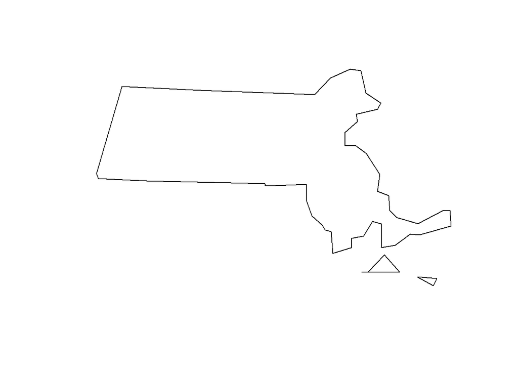

```r
plot(spTransform(mass_border_sp, proj4_aea_sp_2))
```

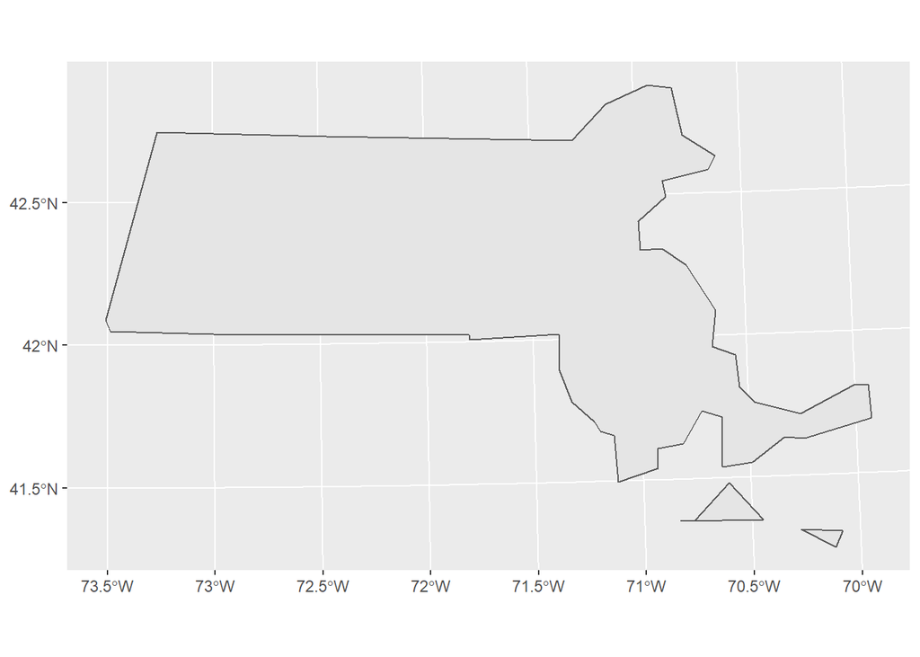

```r
ggplot(st_transform(mass_border_sf, proj4_aea_sf_2)) + geom_sf()
```

Success!